# Optimal Treatment Analysis

## Outcome Variable

**Outcome Variable:** haz

## Predictor Variables

**Intervention Variable:** nhh

**Adjustment Set:**

- arm
- W_mage
- meducyrs
- feducyrs
- hhwealth_quart
- W_mhtcm
- W_mwtkg
- W_mbmi
- W_nrooms
- cleanck
- impfloor
- impsan
- safeh20
- delta_W_mage
- delta_meducyrs
- delta_feducyrs
- delta_hhwealth_quart
- delta_W_mhtcm
- delta_W_mwtkg
- delta_W_mbmi
- delta_W_nrooms
- delta_cleanck
- delta_impfloor
- delta_impsan
- delta_safeh20

## Stratifying Variables

The analysis was stratified on these variable(s):

- agecat
- studyid
- country

## Data Summary

| agecat | studyid | country | nhh | n_cell | n |
| --- | --- | --- | --- | --- | --- |
| Birth | ki1000108-IRC | INDIA | 3 or less | 54 | 388 |
| Birth | ki1000108-IRC | INDIA | 4-5 | 150 | 388 |
| Birth | ki1000108-IRC | INDIA | 6-7 | 103 | 388 |
| Birth | ki1000108-IRC | INDIA | 8+ | 81 | 388 |
| Birth | ki1017093-NIH-Birth | BANGLADESH | 3 or less | 7 | 28 |
| Birth | ki1017093-NIH-Birth | BANGLADESH | 4-5 | 11 | 28 |
| Birth | ki1017093-NIH-Birth | BANGLADESH | 6-7 | 7 | 28 |
| Birth | ki1017093-NIH-Birth | BANGLADESH | 8+ | 3 | 28 |
| Birth | ki1017093c-NIH-Crypto | BANGLADESH | 3 or less | 8 | 27 |
| Birth | ki1017093c-NIH-Crypto | BANGLADESH | 4-5 | 9 | 27 |
| Birth | ki1017093c-NIH-Crypto | BANGLADESH | 6-7 | 7 | 27 |
| Birth | ki1017093c-NIH-Crypto | BANGLADESH | 8+ | 3 | 27 |
| 6 months | ki1000108-IRC | INDIA | 3 or less | 58 | 407 |
| 6 months | ki1000108-IRC | INDIA | 4-5 | 158 | 407 |
| 6 months | ki1000108-IRC | INDIA | 6-7 | 106 | 407 |
| 6 months | ki1000108-IRC | INDIA | 8+ | 85 | 407 |
| 6 months | ki1000304b-SAS-FoodSuppl | INDIA | 3 or less | 33 | 380 |
| 6 months | ki1000304b-SAS-FoodSuppl | INDIA | 4-5 | 166 | 380 |
| 6 months | ki1000304b-SAS-FoodSuppl | INDIA | 6-7 | 115 | 380 |
| 6 months | ki1000304b-SAS-FoodSuppl | INDIA | 8+ | 66 | 380 |
| 6 months | ki1017093-NIH-Birth | BANGLADESH | 3 or less | 95 | 537 |
| 6 months | ki1017093-NIH-Birth | BANGLADESH | 4-5 | 227 | 537 |
| 6 months | ki1017093-NIH-Birth | BANGLADESH | 6-7 | 128 | 537 |
| 6 months | ki1017093-NIH-Birth | BANGLADESH | 8+ | 87 | 537 |
| 6 months | ki1017093b-PROVIDE | BANGLADESH | 3 or less | 102 | 583 |
| 6 months | ki1017093b-PROVIDE | BANGLADESH | 4-5 | 277 | 583 |
| 6 months | ki1017093b-PROVIDE | BANGLADESH | 6-7 | 126 | 583 |
| 6 months | ki1017093b-PROVIDE | BANGLADESH | 8+ | 78 | 583 |
| 6 months | ki1017093c-NIH-Crypto | BANGLADESH | 3 or less | 104 | 715 |
| 6 months | ki1017093c-NIH-Crypto | BANGLADESH | 4-5 | 326 | 715 |
| 6 months | ki1017093c-NIH-Crypto | BANGLADESH | 6-7 | 170 | 715 |
| 6 months | ki1017093c-NIH-Crypto | BANGLADESH | 8+ | 115 | 715 |
| 6 months | ki1148112-LCNI-5 | MALAWI | 3 or less | 224 | 816 |
| 6 months | ki1148112-LCNI-5 | MALAWI | 4-5 | 340 | 816 |
| 6 months | ki1148112-LCNI-5 | MALAWI | 6-7 | 182 | 816 |
| 6 months | ki1148112-LCNI-5 | MALAWI | 8+ | 70 | 816 |
| 24 months | ki1000108-IRC | INDIA | 3 or less | 58 | 409 |
| 24 months | ki1000108-IRC | INDIA | 4-5 | 158 | 409 |
| 24 months | ki1000108-IRC | INDIA | 6-7 | 107 | 409 |
| 24 months | ki1000108-IRC | INDIA | 8+ | 86 | 409 |
| 24 months | ki1017093-NIH-Birth | BANGLADESH | 3 or less | 75 | 429 |
| 24 months | ki1017093-NIH-Birth | BANGLADESH | 4-5 | 184 | 429 |
| 24 months | ki1017093-NIH-Birth | BANGLADESH | 6-7 | 100 | 429 |
| 24 months | ki1017093-NIH-Birth | BANGLADESH | 8+ | 70 | 429 |
| 24 months | ki1017093b-PROVIDE | BANGLADESH | 3 or less | 105 | 577 |
| 24 months | ki1017093b-PROVIDE | BANGLADESH | 4-5 | 273 | 577 |
| 24 months | ki1017093b-PROVIDE | BANGLADESH | 6-7 | 117 | 577 |
| 24 months | ki1017093b-PROVIDE | BANGLADESH | 8+ | 82 | 577 |
| 24 months | ki1017093c-NIH-Crypto | BANGLADESH | 3 or less | 69 | 514 |
| 24 months | ki1017093c-NIH-Crypto | BANGLADESH | 4-5 | 232 | 514 |
| 24 months | ki1017093c-NIH-Crypto | BANGLADESH | 6-7 | 130 | 514 |
| 24 months | ki1017093c-NIH-Crypto | BANGLADESH | 8+ | 83 | 514 |
| 24 months | ki1148112-LCNI-5 | MALAWI | 3 or less | 159 | 574 |
| 24 months | ki1148112-LCNI-5 | MALAWI | 4-5 | 237 | 574 |
| 24 months | ki1148112-LCNI-5 | MALAWI | 6-7 | 129 | 574 |
| 24 months | ki1148112-LCNI-5 | MALAWI | 8+ | 49 | 574 |

The following strata were considered:

- agecat: 24 months, studyid: ki1000108-IRC, country: INDIA
- agecat: 24 months, studyid: ki1017093-NIH-Birth, country: BANGLADESH
- agecat: 24 months, studyid: ki1017093b-PROVIDE, country: BANGLADESH
- agecat: 24 months, studyid: ki1017093c-NIH-Crypto, country: BANGLADESH
- agecat: 24 months, studyid: ki1148112-LCNI-5, country: MALAWI
- agecat: 6 months, studyid: ki1000108-IRC, country: INDIA
- agecat: 6 months, studyid: ki1000304b-SAS-FoodSuppl, country: INDIA
- agecat: 6 months, studyid: ki1017093-NIH-Birth, country: BANGLADESH
- agecat: 6 months, studyid: ki1017093b-PROVIDE, country: BANGLADESH
- agecat: 6 months, studyid: ki1017093c-NIH-Crypto, country: BANGLADESH
- agecat: 6 months, studyid: ki1148112-LCNI-5, country: MALAWI
- agecat: Birth, studyid: ki1000108-IRC, country: INDIA
- agecat: Birth, studyid: ki1017093-NIH-Birth, country: BANGLADESH
- agecat: Birth, studyid: ki1017093c-NIH-Crypto, country: BANGLADESH

### Dropped Strata

Some strata were dropped due to rare outcomes:

- agecat: Birth, studyid: ki1017093-NIH-Birth, country: BANGLADESH
- agecat: Birth, studyid: ki1017093c-NIH-Crypto, country: BANGLADESH

## Methods Detail

We’re interested in the causal parameters $E[Y_a]$ for all values of $a \in \mathcal{A}$. These parameters represent the mean outcome if, possibly contrary to fact, we intervened to set all units to have $A=a$. Under the randomization and positivity assumptions, these are identified by the statistical parameters $\psi_a=E_W[E_{Y|A,W}(Y|A=a,W)]$. In addition, we’re interested in the mean of $Y$, $E[Y]$ under no intervention (the observed mean). We will estimate these parameters by using SuperLearner to fit the relevant likelihood factors – $E_{Y|A,W}(Y|A=a,W)$ and $p(A=a|W)$, and then updating our likelihood fit using a joint TMLE.

For unadjusted analyses ($W=\{\}$), initial likelihoods were estimated using Lrnr_glm to estimate the simple $E(Y|A)$ and Lrnr_mean to estimate $p(A)$. For adjusted analyses, a small library containing Lrnr_glmnet, Lrnr_xgboost, and Lrnr_mean was used.

Having estimated these parameters, we will then use the delta method to estimate relative risks and attributable risks relative to a prespecified baseline level of $A$.

# Results Detail

## Results Plots

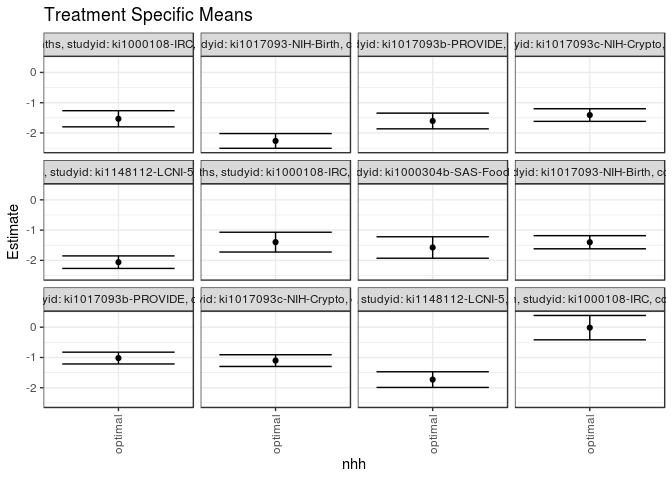

## Results Table

### Parameter: TSM

| agecat | studyid | country | intervention_level | baseline_level | estimate | ci_lower | ci_upper |
| --- | --- | --- | --- | --- | --- | --- | --- |
| Birth | ki1000108-IRC | INDIA | optimal | observed | -0.0148198 | -0.4175435 | 0.3879039 |
| 6 months | ki1000108-IRC | INDIA | optimal | observed | -1.3975943 | -1.7250732 | -1.0701154 |
| 6 months | ki1000304b-SAS-FoodSuppl | INDIA | optimal | observed | -1.5744055 | -1.9289437 | -1.2198674 |
| 6 months | ki1017093-NIH-Birth | BANGLADESH | optimal | observed | -1.4010141 | -1.6179926 | -1.1840356 |
| 6 months | ki1017093b-PROVIDE | BANGLADESH | optimal | observed | -1.0191554 | -1.2145717 | -0.8237392 |
| 6 months | ki1017093c-NIH-Crypto | BANGLADESH | optimal | observed | -1.1028572 | -1.2965445 | -0.9091699 |
| 6 months | ki1148112-LCNI-5 | MALAWI | optimal | observed | -1.7302044 | -1.9889572 | -1.4714515 |
| 24 months | ki1000108-IRC | INDIA | optimal | observed | -1.5302800 | -1.7971743 | -1.2633858 |
| 24 months | ki1017093-NIH-Birth | BANGLADESH | optimal | observed | -2.2626710 | -2.5061288 | -2.0192131 |
| 24 months | ki1017093b-PROVIDE | BANGLADESH | optimal | observed | -1.6035709 | -1.8628847 | -1.3442572 |
| 24 months | ki1017093c-NIH-Crypto | BANGLADESH | optimal | observed | -1.4075462 | -1.6162613 | -1.1988310 |
| 24 months | ki1148112-LCNI-5 | MALAWI | optimal | observed | -2.0592826 | -2.2664403 | -1.8521248 |

### Parameter: E(Y)

| agecat | studyid | country | intervention_level | baseline_level | estimate | ci_lower | ci_upper |
| --- | --- | --- | --- | --- | --- | --- | --- |
| Birth | ki1000108-IRC | INDIA | observed | observed | -0.3080412 | -0.4687931 | -0.1472894 |
| 6 months | ki1000108-IRC | INDIA | observed | observed | -1.2344062 | -1.3658524 | -1.1029600 |
| 6 months | ki1000304b-SAS-FoodSuppl | INDIA | observed | observed | -1.8986842 | -2.0118892 | -1.7854792 |
| 6 months | ki1017093-NIH-Birth | BANGLADESH | observed | observed | -1.4073821 | -1.4960598 | -1.3187043 |
| 6 months | ki1017093b-PROVIDE | BANGLADESH | observed | observed | -1.0871041 | -1.1635539 | -1.0106543 |
| 6 months | ki1017093c-NIH-Crypto | BANGLADESH | observed | observed | -1.1986783 | -1.2700937 | -1.1272630 |
| 6 months | ki1148112-LCNI-5 | MALAWI | observed | observed | -1.6426961 | -1.7120603 | -1.5733318 |
| 24 months | ki1000108-IRC | INDIA | observed | observed | -1.7824776 | -1.8765600 | -1.6883952 |
| 24 months | ki1017093-NIH-Birth | BANGLADESH | observed | observed | -2.1807945 | -2.2835902 | -2.0779987 |
| 24 months | ki1017093b-PROVIDE | BANGLADESH | observed | observed | -1.5861179 | -1.6693668 | -1.5028689 |
| 24 months | ki1017093c-NIH-Crypto | BANGLADESH | observed | observed | -1.4295331 | -1.5127726 | -1.3462935 |
| 24 months | ki1148112-LCNI-5 | MALAWI | observed | observed | -1.8714634 | -1.9528558 | -1.7900711 |

### Parameter: PAR

| agecat | studyid | country | intervention_level | baseline_level | estimate | ci_lower | ci_upper |
| --- | --- | --- | --- | --- | --- | --- | --- |
| Birth | ki1000108-IRC | INDIA | optimal | observed | -0.2932214 | -0.6583080 | 0.0718651 |
| 6 months | ki1000108-IRC | INDIA | optimal | observed | 0.1631881 | -0.1337877 | 0.4601638 |
| 6 months | ki1000304b-SAS-FoodSuppl | INDIA | optimal | observed | -0.3242787 | -0.6676841 | 0.0191267 |
| 6 months | ki1017093-NIH-Birth | BANGLADESH | optimal | observed | -0.0063680 | -0.2036315 | 0.1908955 |
| 6 months | ki1017093b-PROVIDE | BANGLADESH | optimal | observed | -0.0679486 | -0.2497485 | 0.1138513 |
| 6 months | ki1017093c-NIH-Crypto | BANGLADESH | optimal | observed | -0.0958211 | -0.2685368 | 0.0768946 |
| 6 months | ki1148112-LCNI-5 | MALAWI | optimal | observed | 0.0875083 | -0.1549861 | 0.3300027 |
| 24 months | ki1000108-IRC | INDIA | optimal | observed | -0.2521975 | -0.4988852 | -0.0055099 |
| 24 months | ki1017093-NIH-Birth | BANGLADESH | optimal | observed | 0.0818765 | -0.1368440 | 0.3005970 |
| 24 months | ki1017093b-PROVIDE | BANGLADESH | optimal | observed | 0.0174531 | -0.2210525 | 0.2559587 |
| 24 months | ki1017093c-NIH-Crypto | BANGLADESH | optimal | observed | -0.0219869 | -0.2066126 | 0.1626388 |
| 24 months | ki1148112-LCNI-5 | MALAWI | optimal | observed | 0.1878191 | -0.0053779 | 0.3810162 |